# How this package implements Tauc plots

Taha Ahmed

2021-09-07

For direct band gap semiconductors, such as ZnO or CdS, the product of their absorption coefficient $\alpha$ and incident photon energy $hv$ is proportional to the square root of the energy difference between their band gap $E_\text{g}$ and the incident photon energy $E$:

$$\alpha hv \propto (E - E_\text{g})^{1/2}$$

which can be transformed based on the definition of absorbance, $A$, to

$$(Ahv)^2 \propto E - E_\text{g}$$

To determine the optical band gap of a crystalline semiconductor, the ordinate is given by $\alpha^{1/r}$, in which the exponent denotes the nature of the transition:

- $r = 1/2$ for direct allowed transitions,
- $r = 3/2$ for direct forbidden transitions,
- $r = 2$ for indirect allowed transitions,
- $r = 3$ for indirect forbidden transitions.

A Tauc plot is usually performed manually, that is, the band edge region is identified visually, and then a linear fit to the linear part of the band edge is performed manually and the intersect with the abscissa is calculated to arrive at the optical band gap.

If you have a large number of spectra, say from an in-situ experiment, where then band edge is slowly changing (e.g., due to a changing particle size), calculating the band gap for each spectrum quickly becomes tedious.

So a few years ago, I put together some code in R that mostly automated this process, and used it successfully for work that was later published (see Ahmed & Edvinsson, JPCC 2020).

I have now revisited this code, since improved into a semi-automatic algorithm, that only requires you to supply four *x* values: two values that define the “plateau” on the low-energy side of the band edge, and two values that define the “plateau” on the high-energy side of the band edge.

This algorithm returns the calculated optical band gap, as well as the fitted Tauc line itself.

Note that this package expects you to supply the UV-Vis spectrum as absorbance (unitless) vs energy (in electronvolts).

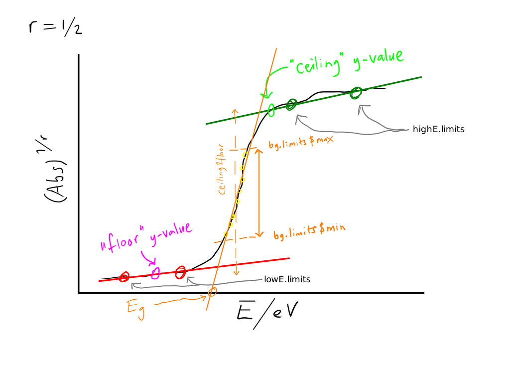

The algorithm uses these values to create two linear fits, that define the “floor” (red line) and “ceiling” (green line) below and above the band edge, respectively. The vertical extent of the band edge can then be calculated (dashed orange line, `ceiling2floor`), and finally a subset of this, whose extent is defined by the input parameter `bg.limits` (which defaults to `c(0.3, 0.8)` of the floor-to-ceiling distance), is used to fit the Tauc line (solid orange line).

This package includes a dataset with 141 UV-Vis spectra from an experiment on growing colloidal ZnO nanoparticles.

```r
UVVisDataZnO <- common::LoadRData2Variable(here::here("data/UVVisDataZnO.rda"))
```

```r
spectrum <-
   UVVisDataZnO %>%
   filter(sampleid == "N04H-00000") %>%
   filter(wavelength < energy2wavelength(3))
spectrum$energy <- photoec::wavelength2energy(spectrum$wavelength)
resdf <-
   uvvistauc::tauc(
      spectrum$energy,
      spectrum$intensity,
      lowE.limits = c(2.8, 3.4),
      highE.limits = c(3.9, 4.3))
```

[figure not shown]

## Notes

- https://en.wikipedia.org/wiki/Tauc_plot
- https://en.wikipedia.org/wiki/Jan_Tauc
- https://en.wikipedia.org/wiki/Band_gap
- Macfarlane, G. G.; Roberts, V. Infrared Absorption of Germanium near the Lattice Edge. Phys. Rev. 1955, 97 (6), 1714–1716. https://doi.org/10.1103/PhysRev.97.1714.2.
- Tauc, J.; Grigorovici, R.; Vancu, A. Optical Properties and Electronic Structure of Amorphous Germanium. Physica Status Solidi 1966, 15, 627–637.
- Tauc, J. Optical Properties and Electronic Structure of Amorphous Ge and Si. Materials Research Bulletin 1968, 3 (1), 37–46. https://doi.org/10.1016/0025-5408(68)90023-8.
- Murphy, A. Band-Gap Determination from Diffuse Reflectance Measurements of Semiconductor Films, and Application to Photoelectrochemical Water-Splitting. Solar Energy Materials and Solar Cells 2007, 91 (14), 1326–1337. https://doi.org/10.1016/j.solmat.2007.05.005.
- Viezbicke, B. D.; Patel, S.; Davis, B. E.; Birnie, D. P. Evaluation of the Tauc Method for Optical Absorption Edge Determination: ZnO Thin Films as a Model System. Physica Status Solidi (B) 2015, 252 (8), 1700–1710. https://doi.org/10.1002/pssb.201552007.
- Ahmed, T.; Edvinsson, T. Optical Quantum Confinement in Ultrasmall ZnO and the Effect of Size on Their Photocatalytic Activity. J. Phys. Chem. C 2020, 124 (11), 6395–6404. https://doi.org/10.1021/acs.jpcc.9b11229.